# How to Use the rstanode Package

Imad Ali

2017-07-15

## Introduction

The purpose of this package is to allow users to simulate and estimate the parameters from a system of ordinary differential equations (ODE) in Stan while not having to write Stan code. Events are supported by providing an event data frame.

Unfortunately, due to the user-defined nature ODE system it is not possible for the Stan model to be precompiled. Thus some compile time will be involve when simulating/fitting the model specified by the user.

**NOTE**: estimating parameters from the ODE (i.e. `sampling = TRUE`) is not yet supported.

## Libraries

Load the **stanode** package and the **deSolve** package (for comparison).

```r
library(rstanode)
library(deSolve)
rstan::rstan_options(auto_write = TRUE)
```

## Simple Harmonic Oscillator

The mathematical representation of a simple harmonic oscillator ODE is,
$$\begin{align}
dy_1 &= y_2 \\
dy_2 &= -y_1 -\theta \cdot y_2
\end{align}$$

In deSolve we can fit a simple harmonic oscillator as follows,

```r
# specify the ODE
sho <- function(t, y, p) {
  with(as.list(c(y,p)), {
    dy1 = y2
    dy2 = - y1 - theta * y2
    return(list(c(dy1 = dy1, dy2 = dy2)))
  })
}
# declare the parameters, initial conditions, and time steps
pars <- c("theta" = 0.15)
yini <- c("y1" = 1, "y2" = 0)
time_steps <- seq(1, 100, by = 0.001)
sho_deSolve <- ode(func = sho, y = yini, times = time_steps, parms = pars)
```

In stanode we can use the same function arguments to simulate from the same model,

```r
sho_stanode <- stan_ode(sho, state = yini,
                  pars = pars,
                  times = time_steps,
                  integrator = "rk45",
                  sampling = FALSE)
sims <- sho_stanode$simulations
```

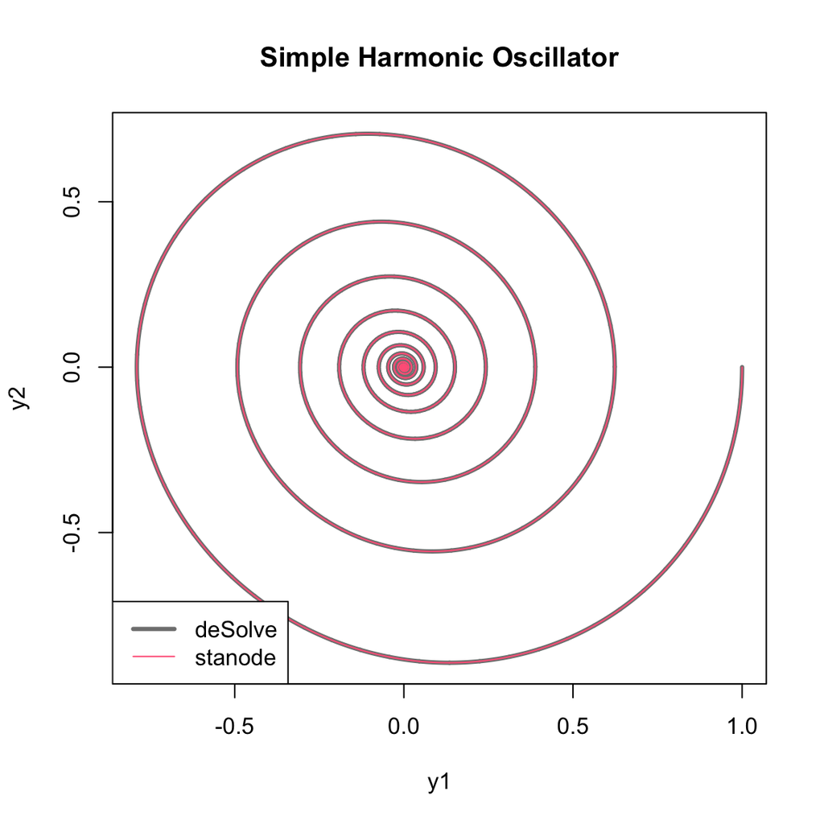

```r
plot(sho_deSolve[,2], sho_deSolve[,3], col = "#808080", lwd = 3,
     type = "l",
     main = "Simple Harmonic Oscillator", xlab = "y1", ylab = "y2")
lines(sims[,2], sims[,3], col = "#FF6688")
legend("bottomleft", c("deSolve","stanode"), col = c("#808080", "#FF6688"), lwd = c(3, 1))
```

## PKPD Model

The stanode package also supports events. Specifically, the user provides an event table to which describes the **time** the event takes place, the value that each **state** should take on at the specfied state, and the **method** to use (currently `"add"` and `"multiply"` are supported).

Below we fit the two compartment PKPD model in deSolve

```r
two_cpt <- function(t, y, parms) {
  with(as.list(c(y, parms)), {
    dy_gut = -ka * y_gut
    dy_cent = ka * y_gut - (CL/V_cent + Q/V_cent) * y_cent + (Q/V_peri) * y_peri
    dy_peri = (Q/V_cent) * y_cent - (Q/V_peri) * y_peri
    return(list(c(dy_gut=dy_gut, dy_cent=dy_cent, dy_peri=dy_peri)))
  })
}
dosing_table <- data.frame(var = "y_gut",
                           time = seq(10, 70, by=10),
                           value = 5,
                           method = "add")
pars <- c("CL" = 10, Q = 13, "V_cent" = 20, "V_peri" = 73, ka = 3)
yini <- c("y_gut" = 0, "y_cent" = 0, "y_peri" = 0)
time_steps <- seq(0, 150, by = 0.005)
two_cpt_deSolve <- deSolve::ode(y = yini, times = time_steps, func = two_cpt, parms = pars,
                                events = list(data = dosing_table))
```

To fit the model in stanode we need to specify the event table,

```r
dosing_table_stan <- data.frame(time = dosing_table$time,
                                "y_gut" = 5, "y_cent" = 0, "y_peri" = 0,
                                method = "add")
print(dosing_table_stan)
```

```
##   time y_gut y_cent y_peri method
## 1   10     5      0      0    add
## 2   20     5      0      0    add
## 3   30     5      0      0    add
## 4   40     5      0      0    add
## 5   50     5      0      0    add
## 6   60     5      0      0    add
## 7   70     5      0      0    add
```

Now we can simulate the model,

```r
two_cpt_stanode <- stan_ode(two_cpt, state = yini,
                            pars = pars,
                            times = time_steps,
                            events = dosing_table_stan,
                            integrator = "rk45",
                            sampling = FALSE)
sims <- two_cpt_stanode$simulations
```

Below we plot the simulations for each compartment from both packages.

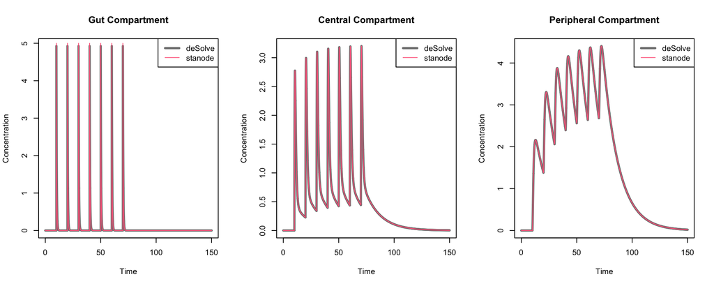

```r
par(mfrow = c(1,3))

plot(two_cpt_deSolve[,1], two_cpt_deSolve[,2], col = "#808080", lwd = 3,
     type = "l",
     main = "Gut Compartment", xlab = "Time", ylab = "Concentration")
lines(sims[,1], sims[,2], col = "#FF6688")
legend("topright", c("deSolve","stanode"), col = c("#808080", "#FF6688"), lwd = c(3, 1))

plot(two_cpt_deSolve[,1], two_cpt_deSolve[,3], col = "#808080", lwd = 3,
     type = "l",
     main = "Central Compartment", xlab = "Time", ylab = "Concentration")
lines(sims[,1], sims[,3], col = "#FF6688")
legend("topright", c("deSolve","stanode"), col = c("#808080", "#FF6688"), lwd = c(3, 1))

plot(two_cpt_deSolve[,1], two_cpt_deSolve[,4], col = "#808080", lwd = 3,
     type = "l",
     main = "Peripheral Compartment", xlab = "Time", ylab = "Concentration")
lines(sims[,1], sims[,4], col = "#FF6688")
legend("topright", c("deSolve","stanode"), col = c("#808080", "#FF6688"), lwd = c(3, 1))
```

## Arenstorf Orbits

```r
Arenstorf <- function(t, y, p) {
  with(as.list(c(y,p)), {
    D1 <- ((y[1] + mu1)^2 + y[2]^2)^(3/2)
    D2 <- ((y[1] - mu2)^2 + y[2]^2)^(3/2)
    dy1 <- y[3]
    dy2 <- y[4]
    dy3 <- y[1] + 2*y[4] - mu2*(y[1]+mu1)/D1 - mu1*(y[1]-mu2)/D2
    dy4 <- y[2] - 2*y[3] - mu2*y[2]/D1 - mu1*y[2]/D2
    return(list( c(dy1, dy2, dy3, dy4) ))
  })
}
```

Simulate in deSolve.

```r
mu1 <- 0.012277471
pars <- c(mu1 = mu1, mu2 = 1 - mu1)
yini <- c(y1 = 0.994, y2 = 0,
          y3 = 0, y4 = -2.00158510637908252240537862224)
time_steps <- seq(from = 0, to = 18, by = 0.01)
orbit_deSolve <- ode(func = Arenstorf, y = yini, parms = pars, times = time_steps)
```

Simulate in rstanode.

```r
orbit_rstanode <- stan_ode(Arenstorf,
                           yini,
                           pars,
                           time_steps,
                           integrator = "rk45")
sims <- orbit_rstanode$simulations
```

Overlay both simulations.

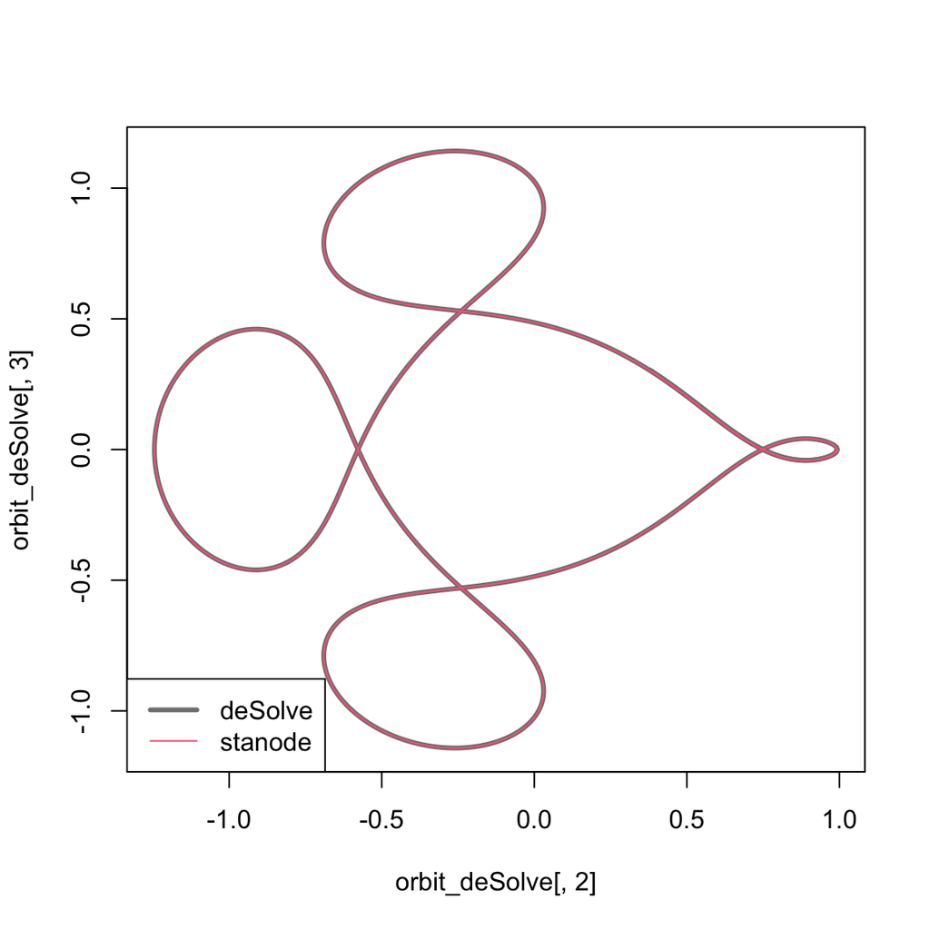

```r
plot(orbit_deSolve[,2], orbit_deSolve[,3], type = "l", col = "#808080", lwd = 3)
lines(sims[,2], sims[,3], col = "#FF6688")
legend("bottomleft", c("deSolve","stanode"), col = c("#808080", "#FF6688"), lwd = c(3, 1))
```